# Extending SORT to Predict Morbidity using the SOuRCe Cohort

#### Regression Model 10

```
## [1] 1056
```

```
## [1] 527
```

```
##
## Call:
## glm(formula = poms ~ asa + factor(opspecialty) + (op_severity >
##     7) + malignancy + (age >= 65 & age < 80) + (age >= 80), family = binomial,
##     data = training)
##
## Deviance Residuals:
##     Min       1Q   Median       3Q      Max
## -1.9263  -0.7321  -0.5780   0.6158   2.7757
##
## Coefficients:
##                          Estimate Std. Error z value Pr(>|z|)
## (Intercept)               -3.9524     0.3792 -10.424  < 2e-16 ***
## asa                        0.5936     0.1245   4.767 1.87e-06 ***
## factor(opspecialty)2       1.6539     0.2210   7.484 7.23e-14 ***
## factor(opspecialty)3      -0.9114     0.4372  -2.084  0.03713 *
## factor(opspecialty)4       0.2805     0.3036   0.924  0.35545
## factor(opspecialty)5      -1.0656     0.4531  -2.352  0.01869 *
## factor(opspecialty)6       0.1732     0.5299   0.327  0.74380
## op_severity > 7TRUE        1.1917     0.2306   5.169 2.36e-07 ***
## malignancy                 0.8980     0.3280   2.737  0.00619 **
## age >= 65 & age < 80TRUE   0.1132     0.1823   0.621  0.53477
## age >= 80TRUE              0.5719     0.2542   2.250  0.02447 *
## ---
## Signif. codes:  0 '***' 0.001 '**' 0.01 '*' 0.05 '.' 0.1 ' ' 1
##
## (Dispersion parameter for binomial family taken to be 1)
##
##     Null deviance: 1198.5  on 1055  degrees of freedom
## Residual deviance: 1044.8  on 1045  degrees of freedom
## AIC: 1066.8
##
## Number of Fisher Scoring iterations: 5
```

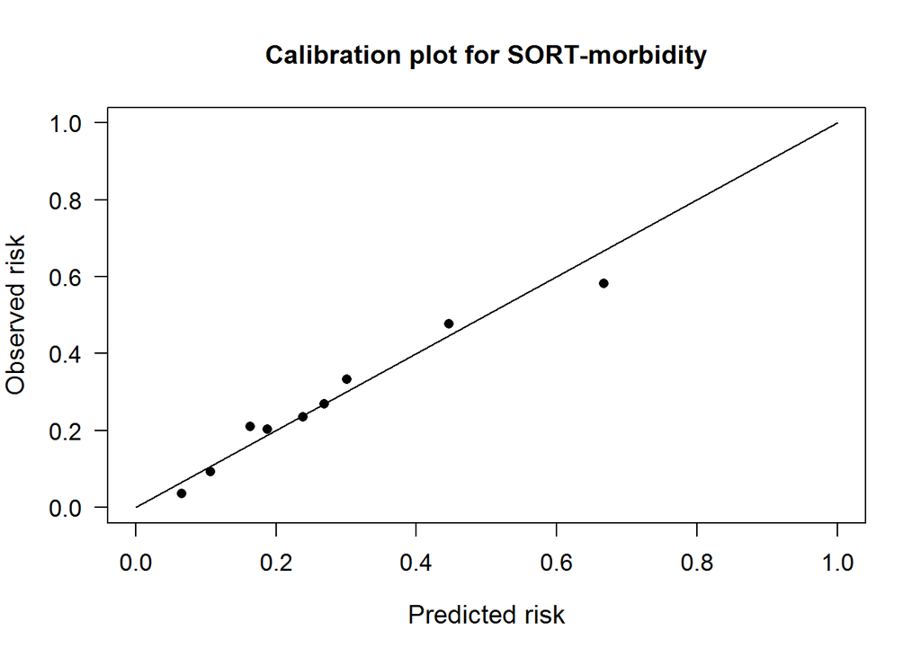

```
## AUC [95% CI] for the model 1 :  0.715 [ 0.665  -  0.765 ]
## AUC [95% CI] for the model 2 :  0.656 [ 0.601  -  0.712 ]
```

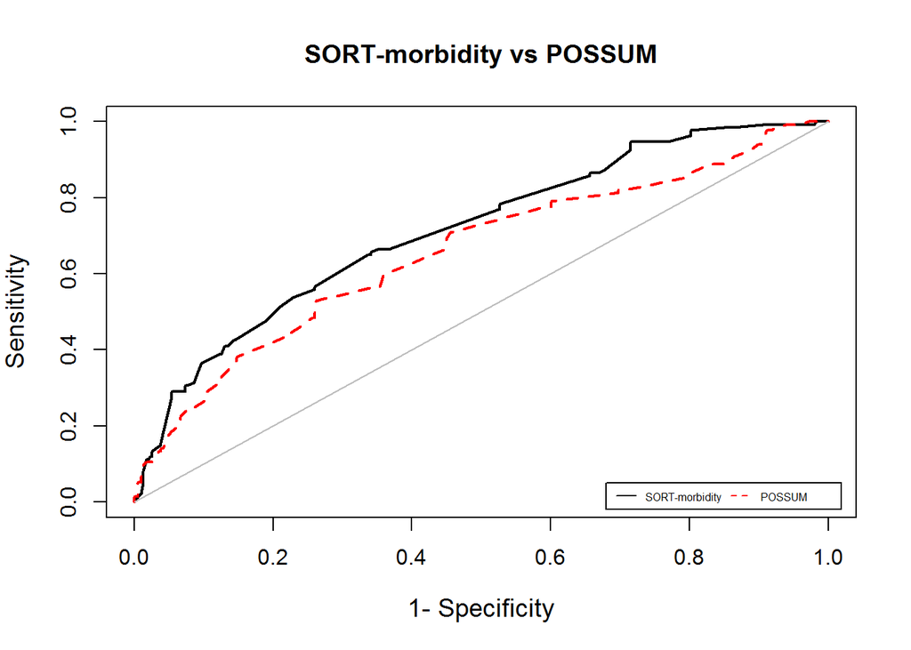

```
##
##  DeLong's test for two correlated ROC curves
##
## data:  roc_model10 and roc_POSSUM
## Z = 1.7727, p-value = 0.07628
## alternative hypothesis: true difference in AUC is not equal to 0
## sample estimates:
## AUC of roc1 AUC of roc2
##   0.7145665   0.6562322
```

```r
library(car)

#Check for multicollinearity
vif(lr_poms10)
```

```
##                          GVIF Df GVIF^(1/(2*Df))
## asa                  1.166086  1        1.079855
## factor(opspecialty)  2.107648  5        1.077407
## op_severity > 7      1.556094  1        1.247435
## malignancy           1.109619  1        1.053384
## age >= 65 & age < 80 1.244317  1        1.115489
## age >= 80            1.200709  1        1.095769
```

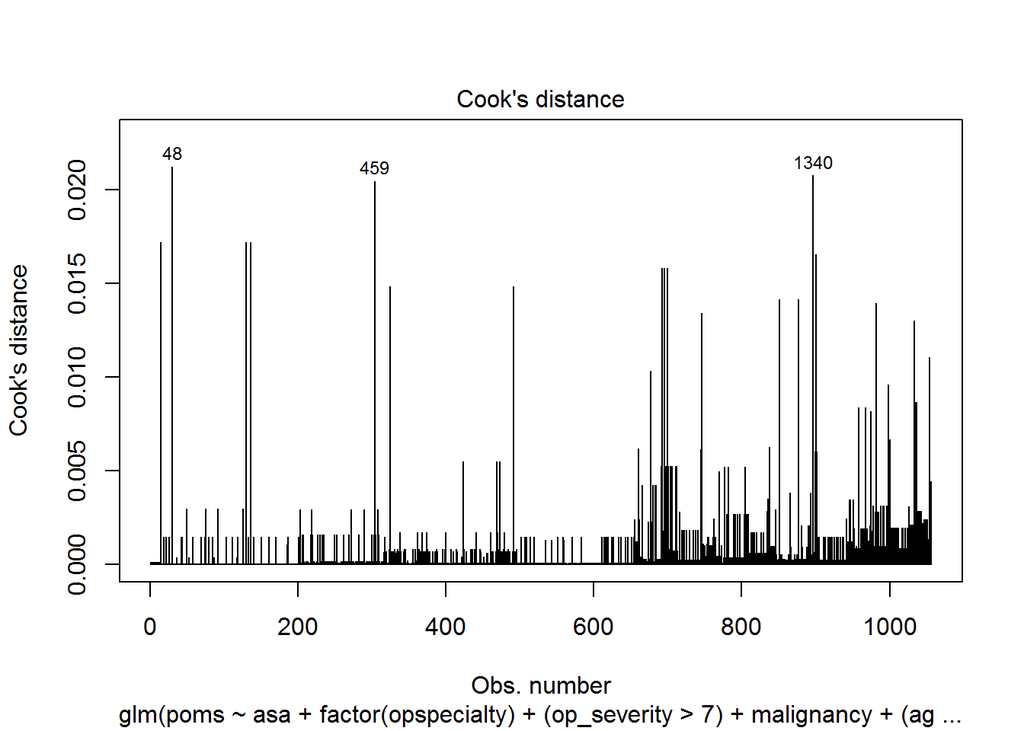

```r
# Cook's D plot
# identify D values > 4/(n-k-1)
cutoff <- 4/((nrow(training)-length(lr_poms10$coefficients)-2))
plot(lr_poms10, which=4, cook.levels=cutoff)
```

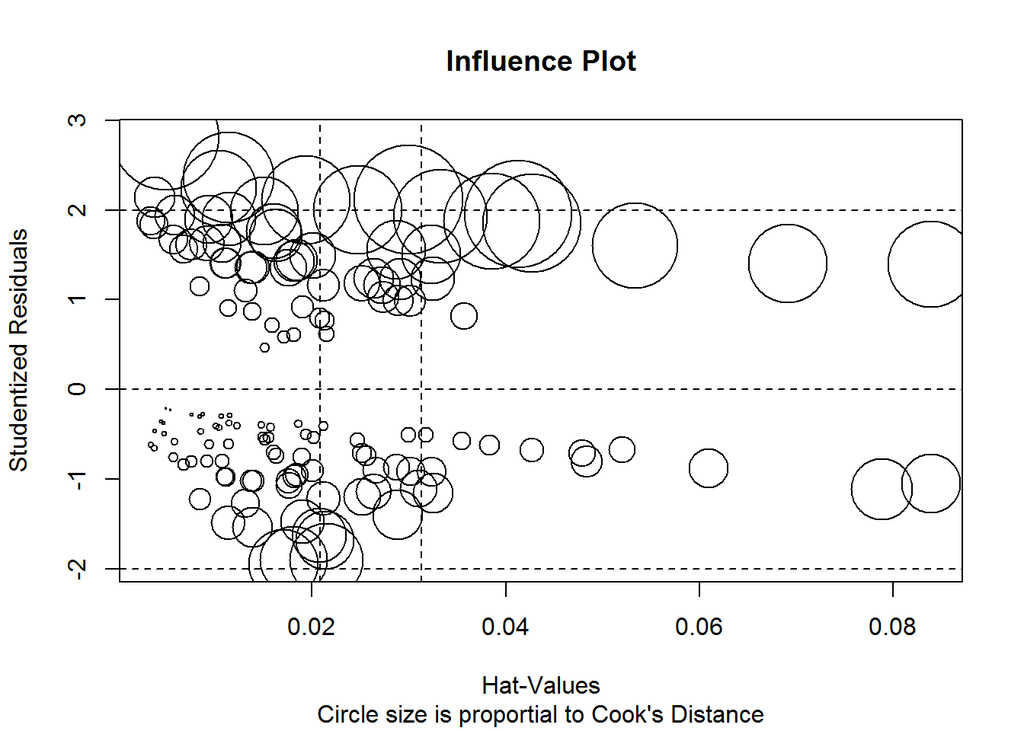

```r
# Influence Plot
influencePlot(lr_poms10,    id.method="identify", main="Influence Plot", sub="Circle size is proportial to Cook's Distance" )
```

#### Regression Model 11

Let’s introduce some interaction terms.

```
## [1] 1056
```

```
## [1] 527
```

```
##
## Call:
## glm(formula = poms ~ asa + factor(opspecialty) + (op_severity >
##     7) + malignancy + (age >= 65 & age < 80) + (age >= 80) +
##     (age >= 65 & age < 80):factor(opspecialty) + (age >= 80):factor(opspecialty),
##     family = binomial, data = training)
##
## Deviance Residuals:
##     Min       1Q   Median       3Q      Max
## -1.9083  -0.7207  -0.5921   0.6530   2.8344
##
## Coefficients: (1 not defined because of singularities)
##                                                Estimate Std. Error z value
## (Intercept)                                    -4.04600    0.39428 -10.262
## asa                                             0.58728    0.12539   4.684
## factor(opspecialty)2                            1.82386    0.26691   6.833
## factor(opspecialty)3                           -1.52219    0.62589  -2.432
## factor(opspecialty)4                            0.78533    0.54858   1.432
## factor(opspecialty)5                           -1.12719    0.50173  -2.247
## factor(opspecialty)6                            0.71612    0.60089   1.192
## op_severity > 7TRUE                             1.21916    0.23006   5.299
## malignancy                                      0.76600    0.33553   2.283
## age >= 65 & age < 80TRUE                        0.10168    0.26442   0.385
## age >= 80TRUE                                   1.03659    0.33007   3.141
## factor(opspecialty)2:age >= 65 & age < 80TRUE   0.01765    0.39677   0.044
## factor(opspecialty)3:age >= 65 & age < 80TRUE   2.83845    1.14021   2.489
## factor(opspecialty)4:age >= 65 & age < 80TRUE  -0.45035    0.68520  -0.657
## factor(opspecialty)5:age >= 65 & age < 80TRUE   1.88693    1.38483   1.363
## factor(opspecialty)6:age >= 65 & age < 80TRUE  -1.01787    1.28099  -0.795
## factor(opspecialty)2:age >= 80TRUE             -1.37305    0.59846  -2.294
## factor(opspecialty)3:age >= 80TRUE             15.35067  882.74369   0.017
## factor(opspecialty)4:age >= 80TRUE             -1.23980    0.83168  -1.491
## factor(opspecialty)5:age >= 80TRUE                   NA         NA      NA
## factor(opspecialty)6:age >= 80TRUE            -14.71122  591.29701  -0.025
##                                               Pr(>|z|)
## (Intercept)                                    < 2e-16 ***
## asa                                           2.82e-06 ***
## factor(opspecialty)2                          8.30e-12 ***
## factor(opspecialty)3                           0.01501 *
## factor(opspecialty)4                           0.15227
```

[output cut: 11 more lines]

```
## factor(opspecialty)2:age >= 80TRUE             0.02177 *
## factor(opspecialty)3:age >= 80TRUE             0.98613
## factor(opspecialty)4:age >= 80TRUE             0.13603
## factor(opspecialty)5:age >= 80TRUE                  NA
## factor(opspecialty)6:age >= 80TRUE             0.98015
## ---
## Signif. codes:  0 '***' 0.001 '**' 0.01 '*' 0.05 '.' 0.1 ' ' 1
##
## (Dispersion parameter for binomial family taken to be 1)
##
##     Null deviance: 1198.5  on 1055  degrees of freedom
## Residual deviance: 1025.1  on 1036  degrees of freedom
## AIC: 1065.1
##
## Number of Fisher Scoring iterations: 13
```

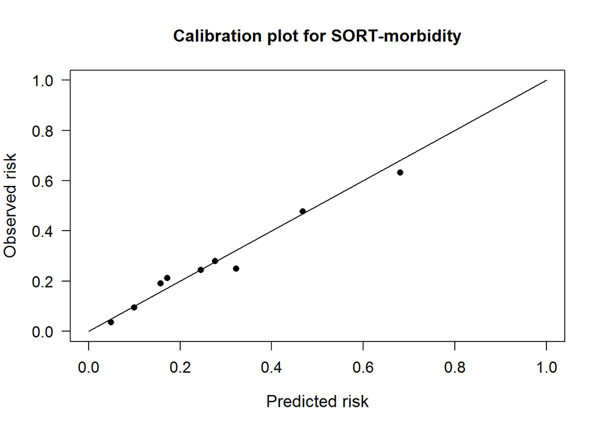

```
## AUC [95% CI] for the model 1 :  0.72 [ 0.67  -  0.77 ]
```

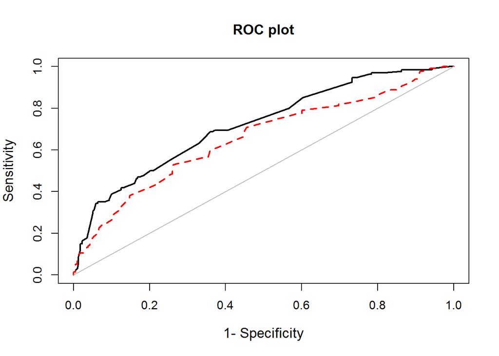

```
## AUC [95% CI] for the model 1 :  0.72 [ 0.67  -  0.77 ]
## AUC [95% CI] for the model 2 :  0.656 [ 0.601  -  0.712 ]
```

```
##
##  DeLong's test for two correlated ROC curves
##
## data:  roc_model11 and roc_POSSUM
## Z = 1.9328, p-value = 0.05325
## alternative hypothesis: true difference in AUC is not equal to 0
## sample estimates:
## AUC of roc1 AUC of roc2
##   0.7203391   0.6562322
```

#### Regression Model Cross Validation

#### Calibration of POSSUM-morbidity

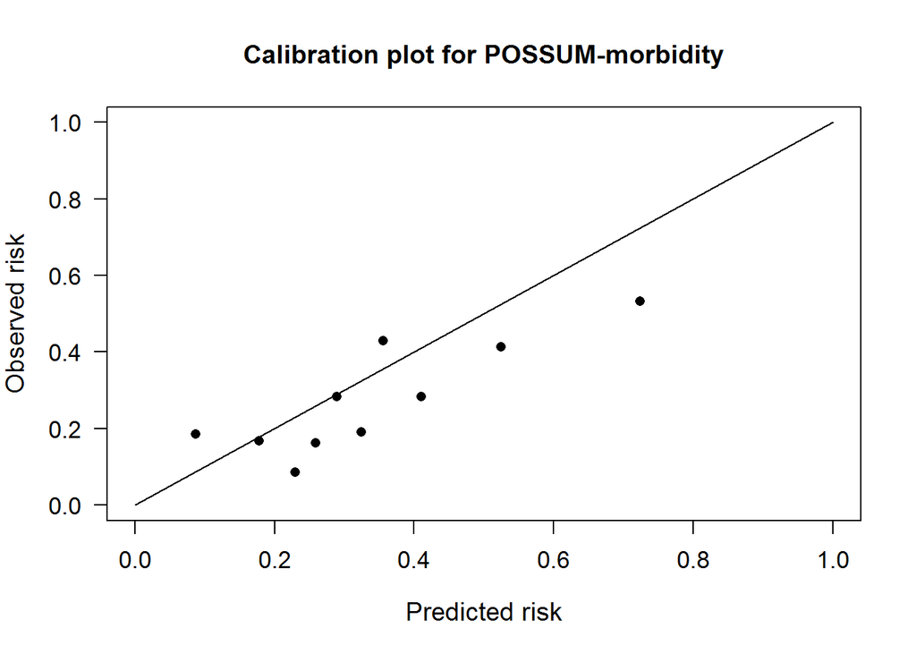

#### POMS as a ordinal outcome with 9 levels?

We may need to consider that POMS as a binary outcome may not be the best measure for “morbidity”. Instead the number of POMS domains may provide a better way of scoring morbidity. We can create a scale 0-9 where 0 is no POMS domains positive on the day it is tested, and each domain that is positive increases the score by 1 to a maximum of 9, since POMS has 9 organ-system domains.

```r
join7 <- join7 %>% mutate(poms_score = pulm + inf + renal + gastro + cardio + neuro + wound + haem + pain) %>% mutate(poms_score = replace(poms_score, which(los < 7 & is.na(poms_score)), 0))

describe(join7$poms_score)
```

```
## join7$poms_score
##        n  missing distinct     Info     Mean      Gmd
##     1583        0        9    0.584   0.5389   0.8962
##
## lowest : 0 1 2 3 4, highest: 4 5 6 7 8
##
## 0 (1180, 0.745), 1 (185, 0.117), 2 (105, 0.066), 3 (51, 0.032), 4 (24,
## 0.015), 5 (25, 0.016), 6 (9, 0.006), 7 (2, 0.001), 8 (2, 0.001)
```

```r
join14 <- join14 %>% mutate(poms_score = pulm + inf + renal + gastro + cardio + neuro + wound + haem + pain) %>% mutate(poms_score = replace(poms_score, which(los < 14 & is.na(poms_score)), 0))

describe(join14$poms_score)
```

```
## join14$poms_score
##        n  missing distinct     Info     Mean      Gmd
##     1753        0        9    0.242   0.2002   0.3775
##
## lowest : 0 1 2 3 4, highest: 4 5 6 7 8
##
## 0 (1598, 0.912), 1 (64, 0.037), 2 (44, 0.025), 3 (20, 0.011), 4 (10,
## 0.006), 5 (9, 0.005), 6 (4, 0.002), 7 (2, 0.001), 8 (2, 0.001)
```

#### Sensitivity analysis

```r
library(dplyr)
library(Hmisc)

#Examine the groups excluded because missing day 7 POMS data
missing_index <- which(!(data_clean$adm_id %in% join7$adm_id))
missing <- data_clean[missing_index,]
describe(missing)
```

```
## missing
##
##  40  Variables      243  Observations
## ---------------------------------------------------------------------------
## X
##        n  missing distinct     Info     Mean      Gmd      .05      .10
##      243        0      243        1    976.6    603.2     89.0    183.0
##      .25      .50      .75      .90      .95
##    526.5   1050.0   1394.5   1652.2   1718.5
##
## lowest :   21   26   27   30   34, highest: 1786 1788 1799 1808 1817
## ---------------------------------------------------------------------------
## adm_id
##        n  missing distinct
##      243        0      243
##
## lowest : 019a8341-e77b-4724-9a5c-b89a4cfa7c65 0230c088-b321-40c7-b3c6-40318a817e14 0426657e-faf1-4c03-b160-cf55c0c61b6b 046d5abd-2e8a-4285-b178-04c3d6c09f37 04772ade-a7af-4e3c-b682-2e3389240a35
## highest: faeae1bf-a225-4b63-b1be-1e7ae98e3403 faeb4542-f64c-4590-b285-dddcc28d3a86 fd0cd879-eb76-4f2b-b121-367801294323 fddeb7e1-fdf4-409c-a2f3-ca77293933bf ffb0f43c-c710-43b2-8f7b-620d68522a57
## ---------------------------------------------------------------------------
## sex
##        n  missing distinct
##      243        0        2
##
## Female (153, 0.63), Male (90, 0.37)
## ---------------------------------------------------------------------------
## age
##        n  missing distinct     Info     Mean      Gmd      .05      .10
##      243        0      241        1    62.41    18.66    26.55    31.47
##      .25      .50      .75      .90      .95
##    55.28    66.94    74.50    80.87    82.83
##
## lowest : 17.34702 18.68036 19.38672 19.86585 21.77687
## highest: 87.14853 87.99179 88.36413 89.34976 89.93840
## ---------------------------------------------------------------------------
## asa
##        n  missing distinct     Info     Mean      Gmd
##      243        0        4    0.741    2.123   0.6233
##
## 1 (32, 0.132), 2 (152, 0.626), 3 (56, 0.230), 4 (3, 0.012)
## ---------------------------------------------------------------------------
```

[output cut: 211 more lines]

```
## srs_mort
##        n  missing distinct     Info     Mean      Gmd
##      243        0        7    0.823  0.02182  0.01388
##
## lowest : 0.0006818628 0.0015780281 0.0036477148 0.0084090681 0.0192652326
## highest: 0.0036477148 0.0084090681 0.0192652326 0.0435216350 0.0953494649
##
## Value      0.0006818628 0.0015780281 0.0036477148 0.0084090681
## Frequency             3            5           12           38
## Proportion        0.012        0.021        0.049        0.156
##
## Value      0.0192652326 0.0435216350 0.0953494649
## Frequency           133           50            2
## Proportion        0.547        0.206        0.008
## ---------------------------------------------------------------------------
```

```r
t.test(missing$age, join7$age)
```

```
##
##  Welch Two Sample t-test
##
## data:  missing$age and join7$age
## t = 2.9138, df = 313.75, p-value = 0.003827
## alternative hypothesis: true difference in means is not equal to 0
## 95 percent confidence interval:
##  1.112344 5.738259
## sample estimates:
## mean of x mean of y
##  62.41368  58.98838
```

```r
t.test(missing$morb_poss, join7$morb_poss)
```

```
##
##  Welch Two Sample t-test
##
## data:  missing$morb_poss and join7$morb_poss
## t = 1.9808, df = 335.66, p-value = 0.04843
## alternative hypothesis: true difference in means is not equal to 0
## 95 percent confidence interval:
##  0.0001503437 0.0431870073
## sample estimates:
## mean of x mean of y
## 0.3416967 0.3200280
```

```r
t.test(missing$p_possmort, join7$p_possmort)
```

```
##
##  Welch Two Sample t-test
##
## data:  missing$p_possmort and join7$p_possmort
## t = 0.25004, df = 406.46, p-value = 0.8027
## alternative hypothesis: true difference in means is not equal to 0
## 95 percent confidence interval:
##  -0.002555180  0.003299924
## sample estimates:
##  mean of x  mean of y
## 0.02043441 0.02006204
```

```r
t.test(missing$srs_mort, join7$srs_mort)
```

```
##
##  Welch Two Sample t-test
##
## data:  missing$srs_mort and join7$srs_mort
## t = 1.3428, df = 339.15, p-value = 0.1802
## alternative hypothesis: true difference in means is not equal to 0
## 95 percent confidence interval:
##  -0.0006233685  0.0033055852
## sample estimates:
## mean of x mean of y
## 0.0218202 0.0204791
```

```r
t.test(missing$sort_mort, join7$sort_mort)
```

```
##
##  Welch Two Sample t-test
##
## data:  missing$sort_mort and join7$sort_mort
## t = -0.2111, df = 425.91, p-value = 0.8329
## alternative hypothesis: true difference in means is not equal to 0
## 95 percent confidence interval:
##  -0.0010063686  0.0008111643
## sample estimates:
##   mean of x   mean of y
## 0.004687562 0.004785164
```

```r
wilcox.test(missing$asa, join7$asa)
```

```
##
##  Wilcoxon rank sum test with continuity correction
##
## data:  missing$asa and join7$asa
## W = 199400, p-value = 0.2924
## alternative hypothesis: true location shift is not equal to 0
```

```r
wilcox.test(missing$los, join7$los)
```

```
##
##  Wilcoxon rank sum test with continuity correction
##
## data:  missing$los and join7$los
## W = 245070, p-value = 4.64e-12
## alternative hypothesis: true location shift is not equal to 0
```

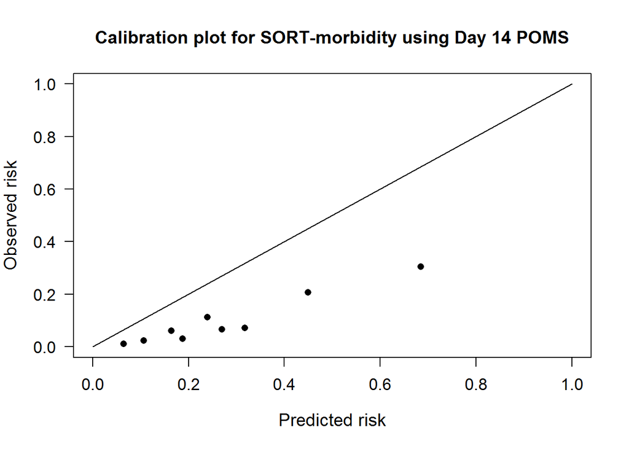

```
## $Table_HLtest
##                 total meanpred meanobs predicted observed
## [0.0118,0.0769)   182    0.065   0.011     11.78        2
## [0.0769,0.1265)   169    0.107   0.024     18.06        4
## [0.1265,0.1864)   362    0.164   0.061     59.54       22
## [0.1864,0.1897)   261    0.188   0.031     49.17        8
## [0.1897,0.2660)   151    0.239   0.113     36.15       17
## [0.2660,0.2931)   137    0.270   0.066     37.05        9
## [0.2931,0.3734)   141    0.317   0.071     44.75       10
## [0.3734,0.5463)   238    0.449   0.206    106.80       49
## [0.5463,0.8951]   112    0.685   0.304     76.66       34
##
## $Chi_square
## [1] 305.915
##
## $df
## [1] 8
##
## $p_value
## [1] 0
```

```r
plotCalibration(data = join14,
                cOutcome = match("poms", colnames(join14)),
                predRisk = predict(lr_poms10, newdata = join14, type = "response"),
                plottitle = "Calibration plot for SORT-morbidity using Day 14 POMS")
```

```r
x <- predict(lr_poms10, newdata = join14, type = "response") #Temp variable
roc_join14model10 <- roc(join14$poms ~ x, plot=FALSE, auc=TRUE, ci=TRUE)
roc_join14POSSUM <- roc(join14$poms ~ join14$morb_poss, plot=FALSE, auc=TRUE, ci=TRUE)

#Test the ROC objects against each other
roc.test(roc_join14model10, roc_join14POSSUM)
```

```
##
##  DeLong's test for two correlated ROC curves
##
## data:  roc_join14model10 and roc_join14POSSUM
## Z = 4.4183, p-value = 9.947e-06
## alternative hypothesis: true difference in AUC is not equal to 0
## sample estimates:
## AUC of roc1 AUC of roc2
##   0.7332411   0.6003452
```

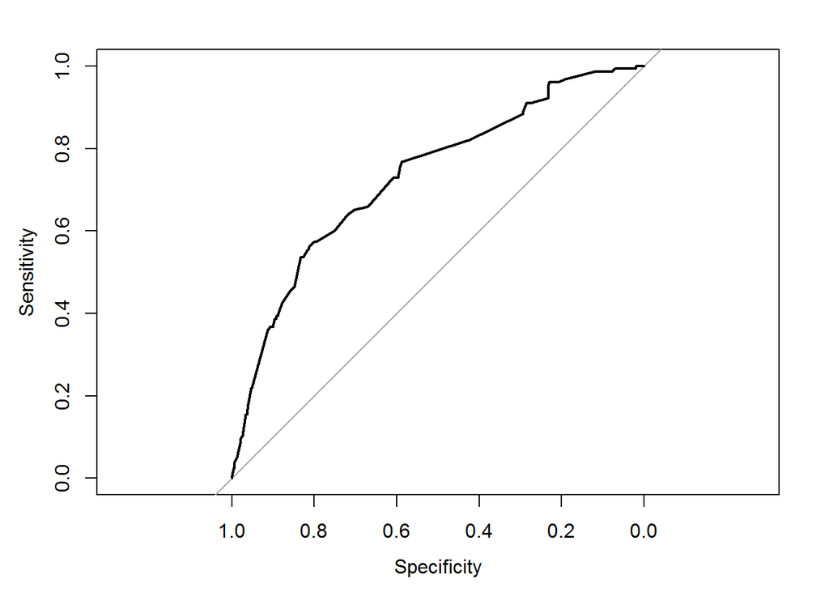

```
##
## Call:
## roc.formula(formula = join14$poms ~ x, plot = FALSE, auc = TRUE,     ci = TRUE)
##
## Data: x in 1598 controls (join14$poms FALSE) < 155 cases (join14$poms TRUE).
## Area under the curve: 0.7332
## 95% CI: 0.6908-0.7757 (DeLong)
```

```r
plot(roc_join14model10)
```

The sensitivity analysis also shows that the SORT-morbidity model has superior discrimination compared to POSSUM when used to predict the presence of POMS-defined morbidity at Day 14 or 15 postoperatively (AUROC = **0.7332411**, **0.6907762, 0.7332411, 0.7757061** vs. **0.6003452**, **0.5497408, 0.6003452, 0.6509496**; z = **4.4183297**, p = **9.946662410^{-6}**).

The BJA Manuscript reviewers have returned with some comments about a sensitivity analysis. This report is an attempt to conduct this.

```r
library(rms)
```

We will use Frank Harrell’s `rms` package to do easily plot calibration curves and obtain AUROCS. The model we will examine is:

```r
summary(lr_poms9)
```

```
##
## Call:
## glm(formula = poms ~ (asa == 2) + (asa == 3) + (asa >= 4) + factor(opspecialty) +
##     (op_severity > 7) + malignancy + (age >= 65 & age < 80) +
##     (age >= 80), family = binomial, data = training)
##
## Deviance Residuals:
##     Min       1Q   Median       3Q      Max
## -1.9860  -0.7118  -0.5906   0.5962   2.8211
##
## Coefficients:
##                          Estimate Std. Error z value Pr(>|z|)
## (Intercept)               -3.2281     0.3250  -9.932  < 2e-16 ***
## asa == 2TRUE               0.3323     0.2287   1.453  0.14626
## asa == 3TRUE               1.1395     0.2574   4.426 9.58e-06 ***
## asa >= 4TRUE               1.2231     0.7431   1.646  0.09978 .
## factor(opspecialty)2       1.6579     0.2213   7.491 6.83e-14 ***
## factor(opspecialty)3      -0.9294     0.4392  -2.116  0.03431 *
## factor(opspecialty)4       0.2962     0.3163   0.937  0.34898
## factor(opspecialty)5      -1.0647     0.4541  -2.345  0.01904 *
## factor(opspecialty)6       0.1807     0.5303   0.341  0.73324
## op_severity > 7TRUE        1.2378     0.2332   5.308 1.11e-07 ***
## malignancy                 0.8968     0.3279   2.735  0.00624 **
## age >= 65 & age < 80TRUE   0.1182     0.1826   0.647  0.51753
## age >= 80TRUE              0.5500     0.2552   2.155  0.03115 *
## ---
## Signif. codes:  0 '***' 0.001 '**' 0.01 '*' 0.05 '.' 0.1 ' ' 1
##
## (Dispersion parameter for binomial family taken to be 1)
##
##     Null deviance: 1198.5  on 1055  degrees of freedom
## Residual deviance: 1042.3  on 1043  degrees of freedom
## AIC: 1068.3
##
## Number of Fisher Scoring iterations: 5
```

## POMS_lo

We have identified some low-grade complications for POMS (e.g. urinary catheter, pain).

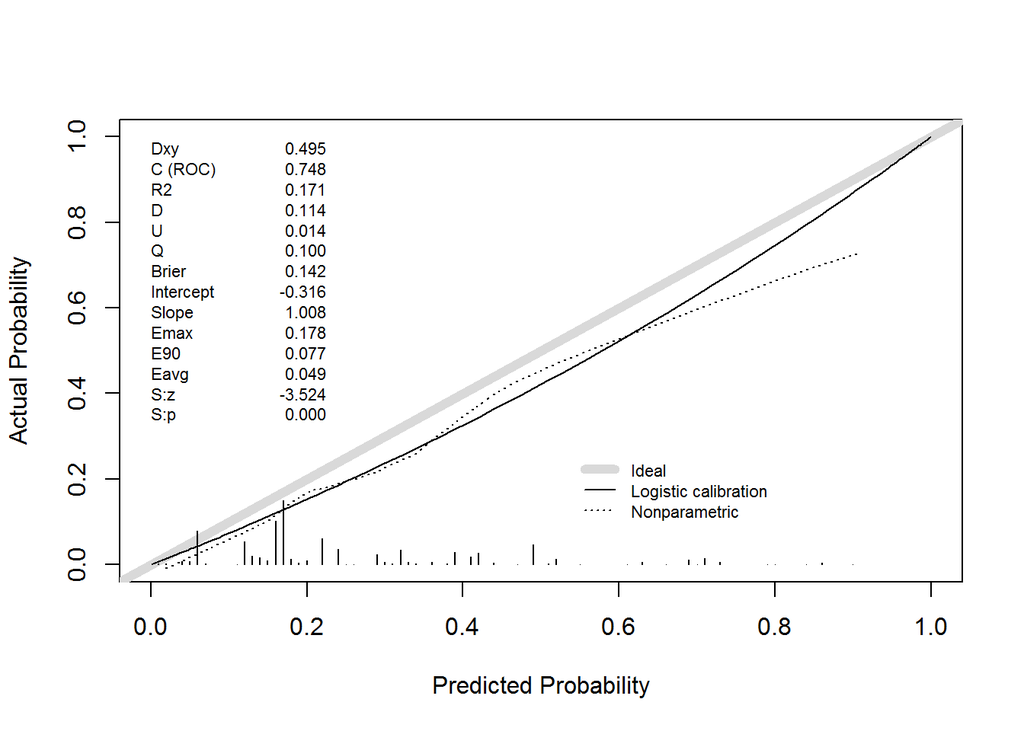

```
##           Dxy       C (ROC)            R2             D      D:Chi-sq
##  4.950408e-01  7.475204e-01  1.710515e-01  1.143925e-01  1.820834e+02
##           D:p             U      U:Chi-sq           U:p             Q
##            NA  1.395459e-02  2.409012e+01  5.873509e-06  1.004379e-01
##         Brier     Intercept         Slope          Emax           E90
##  1.415803e-01 -3.158285e-01  1.007832e+00  1.779985e-01  7.696361e-02
##          Eavg           S:z           S:p
##  4.881226e-02 -3.523574e+00  4.257684e-04
```

```r
val.prob(y = join7$poms_lo, logit = predict(lr_poms9, newdata = join7))
```

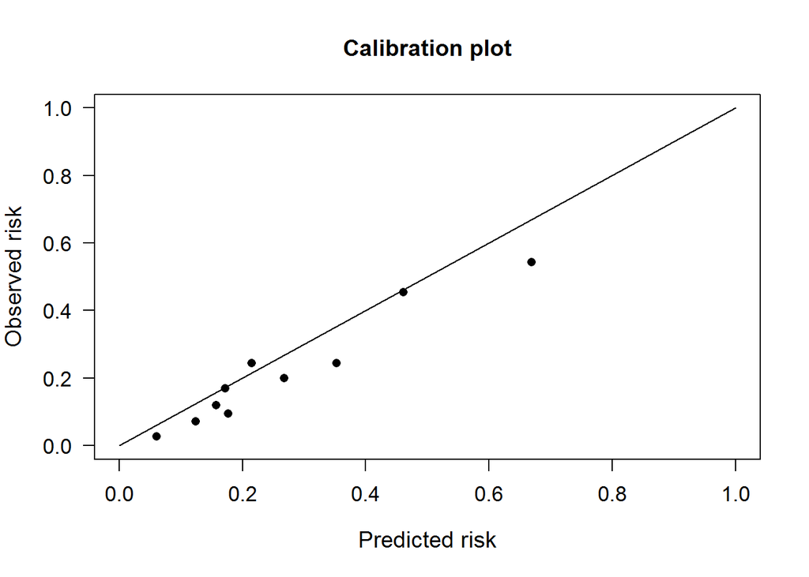

```r
HL_pomslo <- plotCalibration(join7,
                       cOutcome = match("poms_lo", colnames(join7)),
                       predRisk = predict(lr_poms9, newdata = join7, "response"))
```

```r
roc_pomslo <- roc(join7$poms_lo ~ predict(lr_poms9, newdata = join7, "response"), plot=FALSE, auc=TRUE, ci=TRUE)
```

## POMS_hi

Conversely, there are some high-grade complications (e.g. cardiac ischaemia).

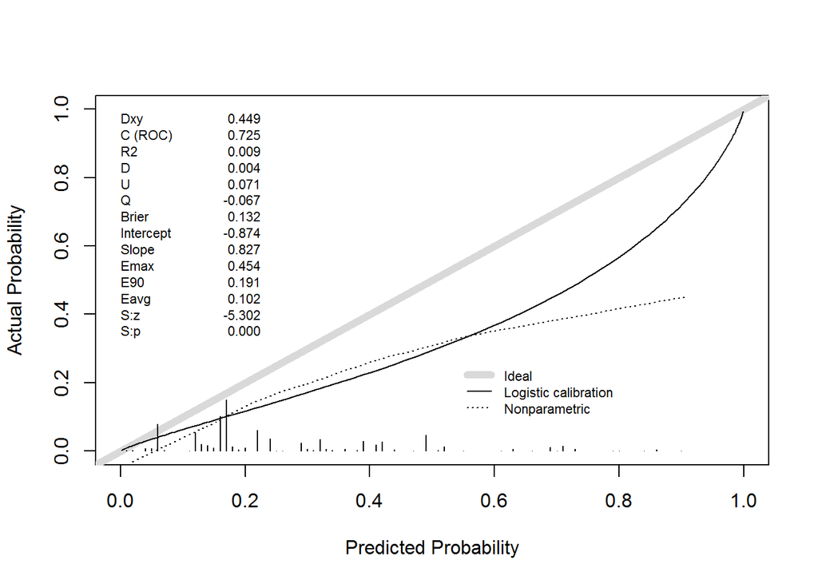

```
##           Dxy       C (ROC)            R2             D      D:Chi-sq
##  4.493923e-01  7.246962e-01  8.506971e-03  4.246795e-03  7.722676e+00
##           D:p             U      U:Chi-sq           U:p             Q
##            NA  7.106473e-02  1.144955e+02  0.000000e+00 -6.681794e-02
##         Brier     Intercept         Slope          Emax           E90
##  1.321966e-01 -8.742130e-01  8.272451e-01  4.544539e-01  1.909423e-01
##          Eavg           S:z           S:p
##  1.016634e-01 -5.301993e+00  1.145454e-07
```

```r
val.prob(y = join7$poms_hi, logit = predict(lr_poms9, newdata = join7))
```

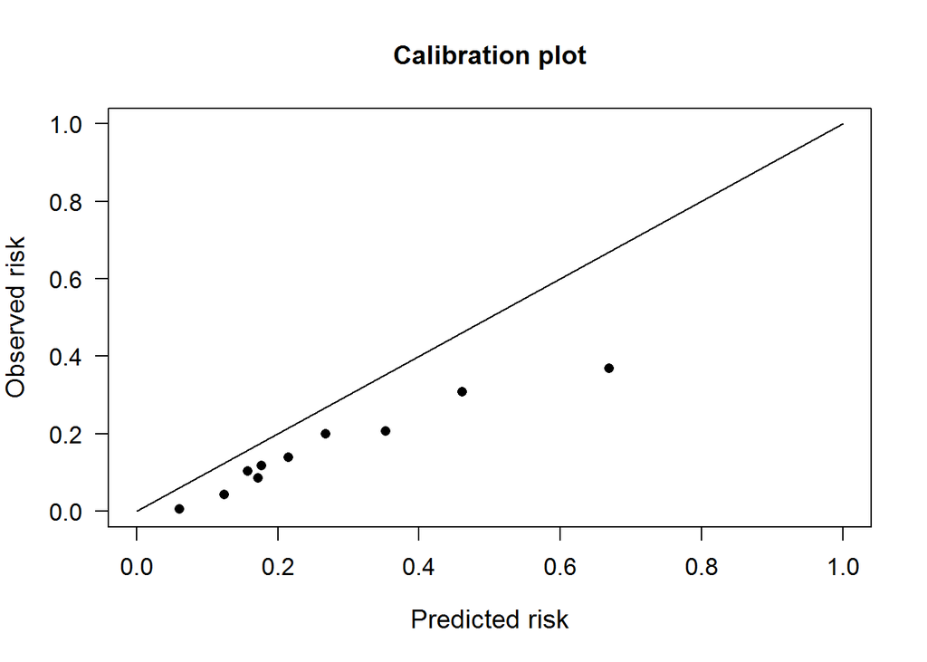

```r
HL_pomshi <- plotCalibration(join7,
                       cOutcome = match("poms_hi", colnames(join7)),
                       predRisk = predict(lr_poms9, newdata = join7, "response"))
```

```r
roc_pomshi <- roc(join7$poms_hi ~ predict(lr_poms9, newdata = join7, "response"), plot=FALSE, auc=TRUE, ci=TRUE)
```

## POMS14

We can also see how well the model predicts POMS outcomes 2 weeks postoperatively.

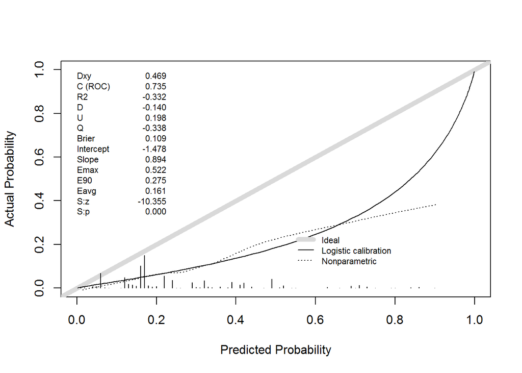

```
##           Dxy       C (ROC)            R2             D      D:Chi-sq
##  4.691388e-01  7.345694e-01 -3.320648e-01 -1.398194e-01 -2.441034e+02
##           D:p             U      U:Chi-sq           U:p             Q
##            NA  1.977038e-01  3.485748e+02  0.000000e+00 -3.375232e-01
##         Brier     Intercept         Slope          Emax           E90
##  1.085156e-01 -1.477501e+00  8.941401e-01  5.224268e-01  2.748685e-01
##          Eavg           S:z           S:p
##  1.609582e-01 -1.035485e+01  3.978216e-25
```

```r
val.prob(y = join14$poms, logit = predict(lr_poms9, newdata = join14))
```

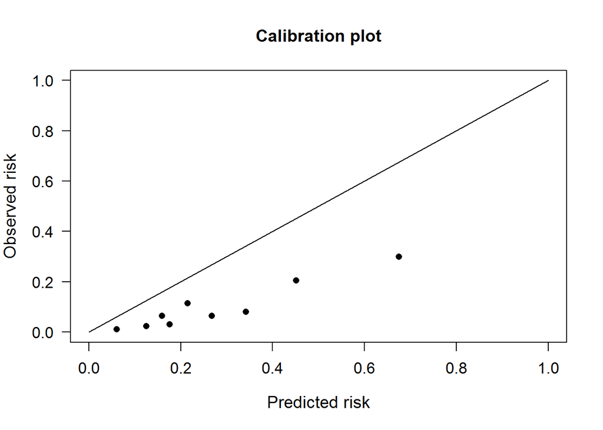

```r
HL_poms14 <- plotCalibration(join14,
                       cOutcome = match("poms", colnames(join14)),
                       predRisk = predict(lr_poms9, newdata = join14, "response"))
```

```r
roc_poms14 <- roc(join14$poms ~ predict(lr_poms9, newdata = join14, "response"), plot=FALSE, auc=TRUE, ci=TRUE)
```

## POMS21

Now we see how well the model predicts POMS outcomes 3 weeks postoperatively.

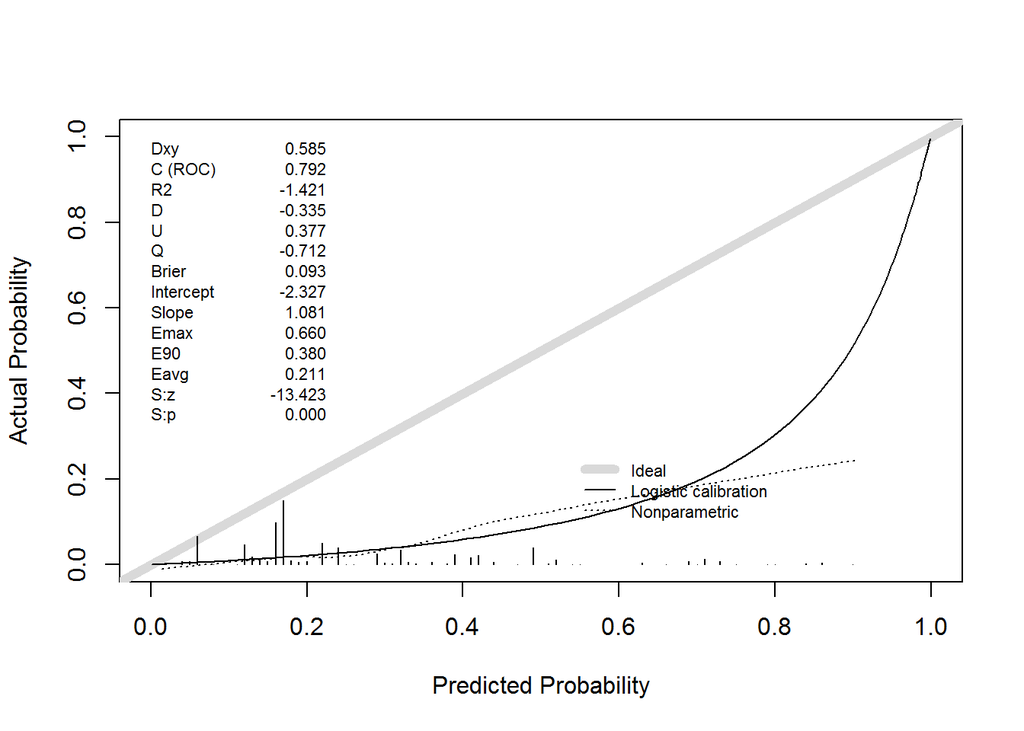

```
##           Dxy       C (ROC)            R2             D      D:Chi-sq
##  5.848879e-01  7.924439e-01 -1.420562e+00 -3.349814e-01 -5.868924e+02
##           D:p             U      U:Chi-sq           U:p             Q
##            NA  3.774939e-01  6.645018e+02  0.000000e+00 -7.124753e-01
##         Brier     Intercept         Slope          Emax           E90
##  9.298428e-02 -2.326692e+00  1.081127e+00  6.603238e-01  3.795625e-01
##          Eavg           S:z           S:p
##  2.105892e-01 -1.342258e+01  4.459248e-41
```

```r
val.prob(y = join21$poms, logit = predict(lr_poms9, newdata = join21))
```

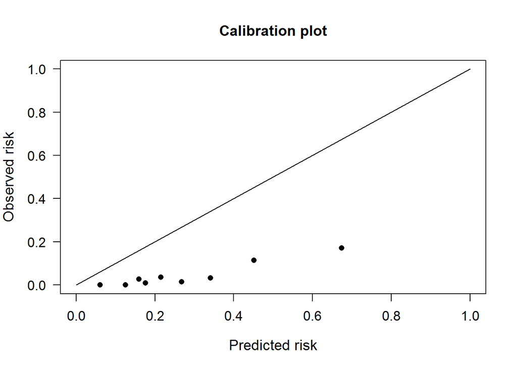

```r
HL_poms21 <- plotCalibration(join21,
                       cOutcome = match("poms", colnames(join21)),
                       predRisk = predict(lr_poms9, newdata = join21, "response"))
```

```r
roc_poms21 <- roc(join21$poms ~ predict(lr_poms9, newdata = join21, "response"), plot=FALSE, auc=TRUE, ci=TRUE)
```

## POMS28

Lastly, we see how well the model predicts POMS outcomes 4 weeks postoperatively.

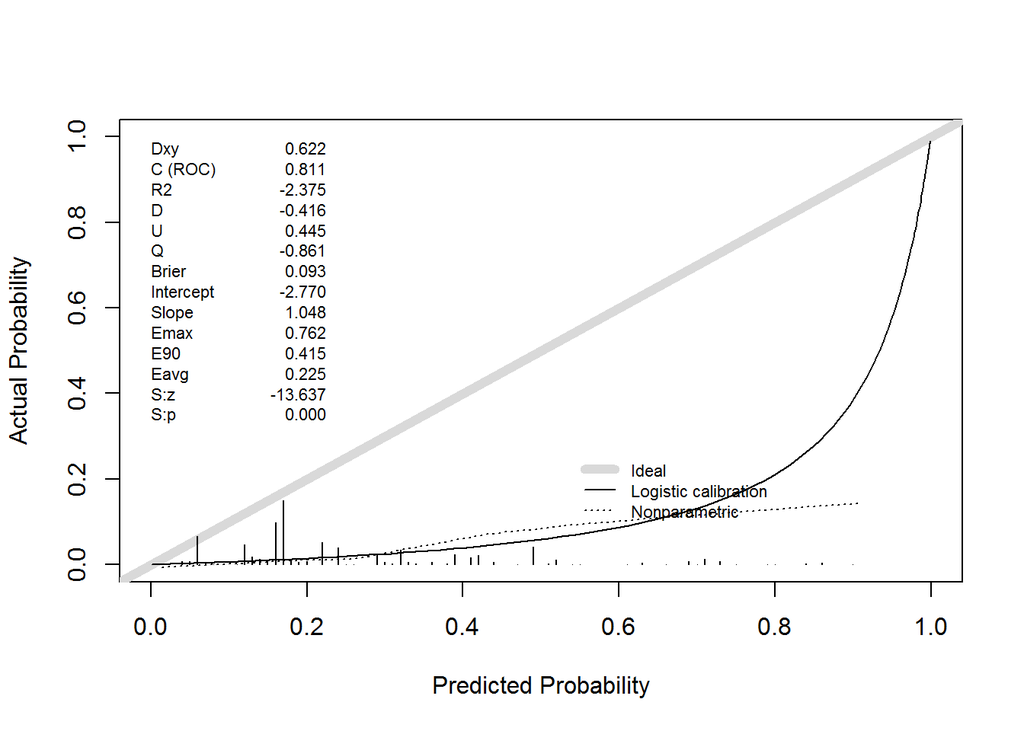

```
##           Dxy       C (ROC)            R2             D      D:Chi-sq
##  6.223219e-01  8.111610e-01 -2.375358e+00 -4.164674e-01 -7.373967e+02
##           D:p             U      U:Chi-sq           U:p             Q
##            NA  4.449196e-01  7.908425e+02  0.000000e+00 -8.613870e-01
##         Brier     Intercept         Slope          Emax           E90
##  9.269795e-02 -2.770420e+00  1.048215e+00  7.618127e-01  4.151957e-01
##          Eavg           S:z           S:p
##  2.247681e-01 -1.363655e+01  2.427874e-42
```

```r
val.prob(y = join28$poms, logit = predict(lr_poms9, newdata = join28))
```

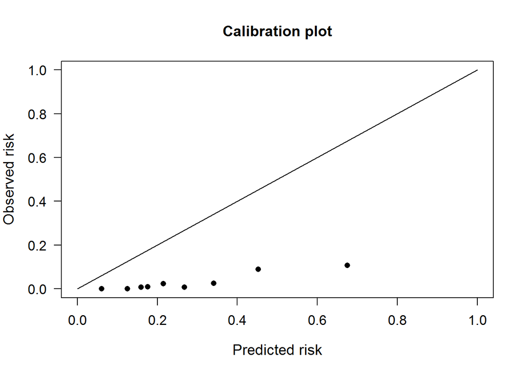

```r
HL_poms28 <- plotCalibration(join28,
                       cOutcome = match("poms", colnames(join28)),
                       predRisk = predict(lr_poms9, newdata = join28, "response"))
```

```r
roc_poms28 <- roc(join28$poms ~ predict(lr_poms9, newdata = join28, "response"), plot=FALSE, auc=TRUE, ci=TRUE)
```

## Interpretation

It looks as though the model is well-calibrated for POMS_lo but mis-calibrated for all the outcomes. However it still remains good at discriminating all the outcomes. Therefore the sensible thing would be to fit another model for the high-grade morbidity outcomes:

```r
#Split the data set into training and testing
set.seed(123)
x <- createDataPartition(join7$poms, p = (2/3), list = FALSE, times = 1)
training <- join7[x, ]
testing <- join7[-x, ]

#Fit a model with the training dataset
lr_poms_hi <- glm(poms_hi ~ (asa == 2) +
                  (asa == 3) +
                  (asa >= 4) +
                  factor(opspecialty) +
                  (op_severity > 7) +
                  malignancy +
                  (age >= 65 & age <80) +
                  (age >= 80),
                data = training,
                family = binomial)

summary(lr_poms9)
```

```
##
## Call:
## glm(formula = poms ~ (asa == 2) + (asa == 3) + (asa >= 4) + factor(opspecialty) +
##     (op_severity > 7) + malignancy + (age >= 65 & age < 80) +
##     (age >= 80), family = binomial, data = training)
##
## Deviance Residuals:
##     Min       1Q   Median       3Q      Max
## -1.9860  -0.7118  -0.5906   0.5962   2.8211
##
## Coefficients:
##                          Estimate Std. Error z value Pr(>|z|)
## (Intercept)               -3.2281     0.3250  -9.932  < 2e-16 ***
## asa == 2TRUE               0.3323     0.2287   1.453  0.14626
## asa == 3TRUE               1.1395     0.2574   4.426 9.58e-06 ***
## asa >= 4TRUE               1.2231     0.7431   1.646  0.09978 .
## factor(opspecialty)2       1.6579     0.2213   7.491 6.83e-14 ***
## factor(opspecialty)3      -0.9294     0.4392  -2.116  0.03431 *
## factor(opspecialty)4       0.2962     0.3163   0.937  0.34898
## factor(opspecialty)5      -1.0647     0.4541  -2.345  0.01904 *
## factor(opspecialty)6       0.1807     0.5303   0.341  0.73324
## op_severity > 7TRUE        1.2378     0.2332   5.308 1.11e-07 ***
## malignancy                 0.8968     0.3279   2.735  0.00624 **
## age >= 65 & age < 80TRUE   0.1182     0.1826   0.647  0.51753
## age >= 80TRUE              0.5500     0.2552   2.155  0.03115 *
## ---
## Signif. codes:  0 '***' 0.001 '**' 0.01 '*' 0.05 '.' 0.1 ' ' 1
##
## (Dispersion parameter for binomial family taken to be 1)
##
##     Null deviance: 1198.5  on 1055  degrees of freedom
## Residual deviance: 1042.3  on 1043  degrees of freedom
## AIC: 1068.3
##
## Number of Fisher Scoring iterations: 5
```

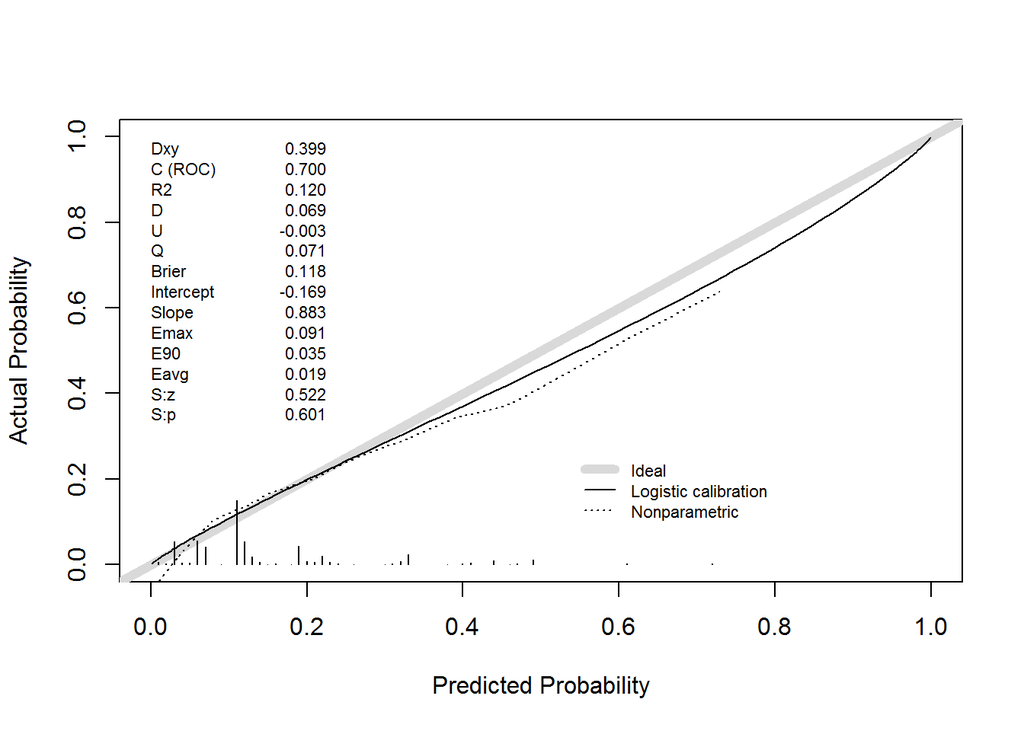

```
##          Dxy      C (ROC)           R2            D     D:Chi-sq
##  0.399186257  0.699593128  0.119703958  0.068834868 37.275975326
##          D:p            U     U:Chi-sq          U:p            Q
##           NA -0.002641733  0.607806771  0.737932158  0.071476601
##        Brier    Intercept        Slope         Emax          E90
##  0.118276423 -0.169306583  0.883451908  0.090627914  0.035036177
##         Eavg          S:z          S:p
##  0.019355148  0.522449243  0.601357577
```

```r
val.prob(y = testing$poms_hi, logit = predict(lr_poms_hi, newdata = testing))
```